# Generating cell-type dataset for AIBS 2018

Regina H. Reynolds

UCL

20 July 2022

> Aim: generate cell-type dataset for AIBS 2018

# 1 Methods

## 1.1 Expression-weighted cell-type enrichment

Specificity values for expression-weighted cell-type enrichment (EWCE) (https://www.bioconductor.org/packages/release/bioc/html/EWCE.html; PMID: [26858593](https://pubmed.ncbi.nlm.nih.gov/26858593/)) analyses were calculated from the Allen Institute for Brain Science (AIBS) study of 49,495 single-nucleus transcriptomes across multiple human cortical areas (Dataset: Allen Institute for Brain Science (2021). Allen Cell Types Database – Human Multiple Cortical Areas [dataset]. Available from celltypes.brain-map.org/rnaseq.)

Specificity values were generated using gene-level exonic and intronic reads. Nuclei from all sampled brain regions were used, which included: the middle temporal gyrus (MTG); anterior cingulate cortex (ACC; also known as the ventral division of medial prefrontal cortex, A24); primary visual cortex (V1C); primary motor cortex (M1C); primary somatosensory cortex (S1C) and primary auditory cortex (A1C). Nuclei were annotated to cell types at two levels, each corresponding to increasingly refined cell-type/-subtype annotations. These cell type labels were derived from the accompanying metadata. Level 1 cell types included 7 types of glutamatergic neuron classified by their projection properties, 5 types of GABAergic neuron classified by marker genes and finally 5 non-neuronal cell types. As the number of nuclei labelled as endothelial cells (n = 70), pericytes (n = 32) and VLMC (n = 11) was low, these were merged into the level 1 cell type, “vascular cell”. Level 2 cell types represented the 120 clusters originally identified in the dataset. For a description of how clustering was performed, please refer to: https://portal.brain-map.org/atlases-and-data/rnaseq/protocols-human-cortex.

Nuclei that were labelled as “outlier calls” in the accompanying metadata (n = 1985) were removed from the analysis. In addition, the following filtering steps were applied to genes: (i) removal of any genes symbols from the gene-cell matrix that were not official HGNC symbols using `EWCE::fix_bad_hgnc_symbols()` (n = 30792 genes were retained); (ii) removal of genes not expressed across any cell types (n = 1263); and (iii) removal of genes that were not significantly differentially expressed across level 2 cell types (n = 6304). Steps (ii) and (iii) were achieved using `EWCE::drop_uninformative_genes()`. The default LIMMA method was used together with an adjusted p-value threshold for differential expression of p < 1e-5. The filtered matrix was then run through `EWCE::generate_celltype_data()` to generate specificity values.

# 2 Supplementary code

Following section includes any intermediary code used in this `.Rmd`.

## 2.1 File paths for `.rmd`

```r
# File paths
args <-
  list(
    data_dir = file.path("/home/rreynolds/data/scRNAseq_AIBS/multiple_cortical_smartseq")
  )

args <-
  c(
    args,
    list(
      path_to_ctd = file.path(args$data_dir, "ctd_aibsMultipleCrtxSmrtSeq.rda"),
      path_to_metadata = file.path(args$data_dir, "metadata.csv")
    )
  )
```

## 2.2 Set up `ewce` docker image

We used the `ewce` docker image (neurogenomicslab/ewce), which also includes RStudio.

This first requires that we download the docker image.

```bash
docker pull neurogenomicslab/ewce:1.5.2
```

Next, we can run an R Studio server instance on rocker-based image, using [docker_run_rserver()](https://rytenlab.github.io/rockup/reference/docker_run_rserver.html) and the following [guide](https://rytenlab.github.io/rockup/articles/rockup.html), both developed by David Zhang.

```r
rockup::docker_run_rserver(
  image = "neurogenomicslab/ewce:1.5.2",
  port = 8992,
  password = "bioc",
  name = "rhr_ewce",
  detach = TRUE,
  rm = FALSE,
  volumes = c(
    "/home/rreynolds/misc_projects/sonia-missplicing/",
    "/home/rreynolds/data"
  ),
  permissions = "match",
  USERID = 1003,
  GROUPID = 1004,
  verbose = TRUE,
  return_flags = FALSE
)
```

Finally, we can access the R Studio server process by mapping the localhost of our local machine to the port on the remote server presenting R Studio server (specified above as 8992). Simply replace the `user` and `ip` values with the appropriate username and IP address for the remote server used.

```bash
ssh -X -N -f -L localhost:8992:localhost:8992 user@ip
```

## 2.3 Generating cell-type dataset for AIBS 2018, multiple cortical areas

```r
metadata <-
  readr::read_csv(args$path_to_metadata)
```

- Data was downloaded from: https://portal.brain-map.org/atlases-and-data/rnaseq/human-multiple-cortical-areas-smart-seq
- Matrices with exon and intron counts were used.
- Used all brain regions sampled, which included:
  - Middle temporal gyrus (MTG)
  - Anterior cingulate cortex (ACC; also known as the ventral division of medial prefrontal cortex, A24)
  - Primary visual cortex (V1C)
  - Primary motor cortex (M1C) - upper (ul) and lower (lm) limb regions
  - Primary somatosensory cortex (S1C) - upper (ul) and lower (lm) regions
  - Primary auditory cortex (A1C)
- Generating cell type annotations
  - Level 1: Allen Brain Atlas provided a class and subclass label. Class had only 3 levels (GABAergic, glutamatergic and non-neuronal), thus instead the subclass label, which subdivided glutamatergic neurons into 7 subtypes, GABAergic neurons into 5 subtypes, and non-neuronal cell types into Astrocyte, Endothelial, Microglia, Oligodendrocyte, OPC, Pericyte, VLMC. As the number of endothelial cells (n = 70), pericytes (n = 32) and VLMC (n = 11) nuclei was low, these were merged into the class “vascular cell”.
  - Level 2: used the original clusters defined by the Allen Brain Atlas
- 1985 nuclei were labelled as “outlier calls”. These were removed during generation of the celltype dataset.
- Used `EWCE::fix_bad_hgnc_symbols()` to remove any symbols from the gene-cell matrix that were not official HGNC symbols. 30792 genes were retained.
- Used `EWCE::drop_uninformative_genes()`, which removes “uninformatic genes” to reduce compute time in susbequent steps. The following steps were performed:
  - Drop non-expressed genes (n = 1263): removes genes that are not expressed across any cell types
  - Drop non-differentially expressed genes (n = 6304): removes genes that are not significantly differentially expressed across level 2 cell types. Default LIMMA used with adjusted p-value threshold of 1e-05.
- Finally, used `EWCE::generate_celltype_data()` to generate the celltype dataset.

```bash
nohup Rscript \
/home/rreynolds/misc_projects/sonia-missplicing/scripts/02a_generate_aibs_ctd.R \
&>/home/rreynolds/misc_projects/sonia-missplicing/logs/02a_generate_aibs_ctd.log&
```

## 2.4 Loading results

```r
ctd <- EWCE::load_rdata(args$path_to_ctd)

annotation <-
  metadata %>%
  dplyr::filter(outlier_call == FALSE) %>%
  dplyr::mutate(
    level1class =
      dplyr::case_when(
        class_label == "Non-neuronal" &
          subclass_label %in% c("Oligodendrocyte", "OPC", "Astrocyte", "Microglia") ~ subclass_label,
        class_label == "Non-neuronal" &
          subclass_label %in% c("Endothelial", "Pericyte", "VLMC") ~ "Vascular_cells",
        TRUE ~ stringr::str_c(
          class_label,
          "_",
          EWCE::fix_celltype_names(subclass_label)
        )
      ),
    level2class =
      cluster_label %>%
      EWCE::fix_celltype_names()
  )
```

# 3 Results

## 3.1 Description of celltype data

### 3.1.1 Text

- Level 1 cell types: 17 different level 1 cell types, with the smallest being vascular cells and the largest being glutamatergic intratelencephalic (IT) neurons (Figure 3.1).
- Level 2 cell types: 120 different level 2 cell types. Noteworthy that 48 level 2 cells types were defined by < 100 nuclei.

### 3.1.2 Tables

Table of level 1 and level 2 cell types.

```r
annotation %>%
  dplyr::distinct(level1class, level2class) %>%
  DT::datatable(rownames = FALSE,
                options = list(scrollX = TRUE),
                class = 'white-space: nowrap')
```

| level1class | level2class |
| --- | --- |
| GABAergic_VIP | Inh_L2_5_VIP_TOX2 |
| GABAergic_LAMP5 | Inh_L1_LAMP5_GGT8P |
| GABAergic_LAMP5 | Inh_L1_LAMP5_NDNF |
| GABAergic_VIP | Inh_L1_3_VIP_ZNF322P1 |
| GABAergic_VIP | Inh_L3_VIP_CBLN1 |
| GABAergic_LAMP5 | Inh_L1_4_LAMP5_DUSP4 |
| Glutamatergic_IT | Exc_L2_3_LINC00507_RPL9P17 |
| GABAergic_VIP | Inh_L1_SST_CXCL14 |
| GABAergic_PAX6 | Inh_L1_PAX6_GRIP2 |
| GABAergic_VIP | Inh_L1_2_VIP_PPAPDC1A |

[output cut: 110 more lines]

Level 2 cell types in descending order of number of nuclei.

```r
annotation %>%
  dplyr::count(level1class, level2class) %>%
  dplyr::arrange(-n) %>%
  DT::datatable(rownames = FALSE,
                options = list(scrollX = TRUE),
                class = 'white-space: nowrap')
```

| level1class | level2class | n |
| --- | --- | --- |
| Glutamatergic_IT | Exc_L2_3_LINC00507_RPL9P17 | 6502 |
| Glutamatergic_IT | Exc_L6_THEMIS_LINC00343 | 2852 |
| Glutamatergic_IT | Exc_L4_5_RORB_LINC01474 | 2254 |
| Glutamatergic_IT | Exc_L4_5_RORB_RPL31P31 | 2016 |
| Oligodendrocyte | Oligo_L4_6_OPALIN | 1676 |
| Glutamatergic_L4_IT | Exc_L2_4_RORB_GRIK1 | 1556 |
| Glutamatergic_IT | Exc_L4_5_RORB_LCN15 | 1262 |
| Glutamatergic_L4_IT | Exc_L4_RORB_BHLHE22 | 1171 |
| Glutamatergic_L6_CT | Exc_L6_FEZF2_FAM95C | 1086 |
| GABAergic_SST | Inh_L3_5_SST_MAFB | 1015 |

[output cut: 110 more lines]

### 3.1.3 Figures

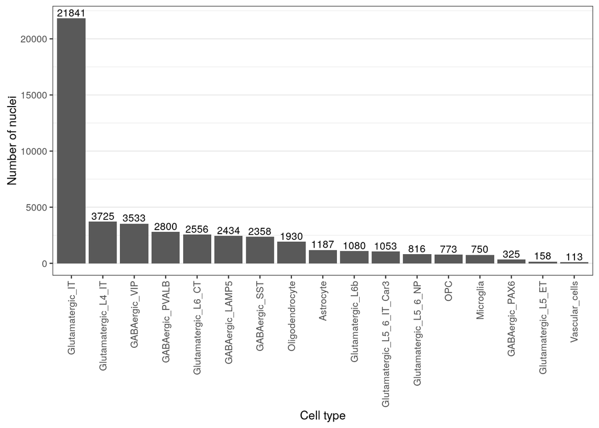

Figure 3.1: Number of nuclei per level 1 cell type class. Glutamatergic classifications by their projection properties: CT = corticothalamic projecting; ET = extratelencephalic projecting; NP = near-projecting; IT = intratelencephalic; L* = cortical layer *. GABAergic classifications by marker genes: LAMP5 = Lysosomal Associated Membrane Protein Family Member 5; PAX6 = Paired box protein Pax-6; PVALB = parvalbumin; SST = somatostatin; VIP = vasoactive intestinal polypeptide. Non-neuronal abbreviations: OPC = oligodendrocyte precursor cell.

```r
annotation %>%
  dplyr::count(level1class) %>%
  ggplot(
    aes(
      x =
        forcats::fct_reorder(.f = level1class, .x = n, .fun = median, .desc = T),
      y = n
    )
  ) +
  geom_col() +
  geom_text(
    aes(label = n),
    size = 3,
    vjust = -0.25
    ) +
  labs(
    x = "Cell type",
    y = "Number of nuclei"
  )
```

# 4 Session info

**Show/hide**